# Applied Microeconometrics

### Different Bandwidths on Smoothing

Results need to be robust to different bandwidths, and need to report results for both estimation types (polynomial in X and local inear regression). We also need to show that including higher order polynomials does not substantially affect our findings, and our results are not affected if we vary the window around the cutoff (stanard errors may go up but hopefully the point estimate doesnt change).

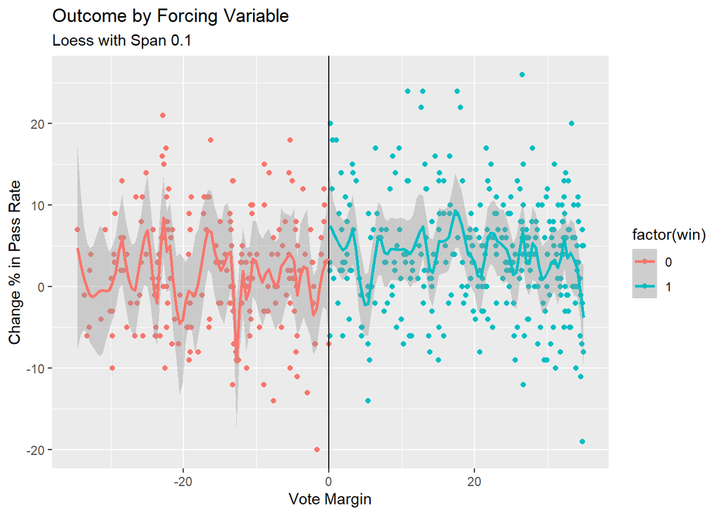

```r
par(mfrow=c(2,2))
g <-
  ggplot(df, aes(x=margin, y=change_pass)) +
  geom_point(aes(color=factor(win))) +
  geom_vline(xintercept=0) +
  labs(x='Vote Margin',
       y='Change % in Pass Rate',
       title='Outcome by Forcing Variable')

g + geom_smooth(method='loess', span=0.1, aes(color=factor(win))) +
  labs(subtitle='Loess with Span 0.1')
```

Increase bandwith to 0.3.

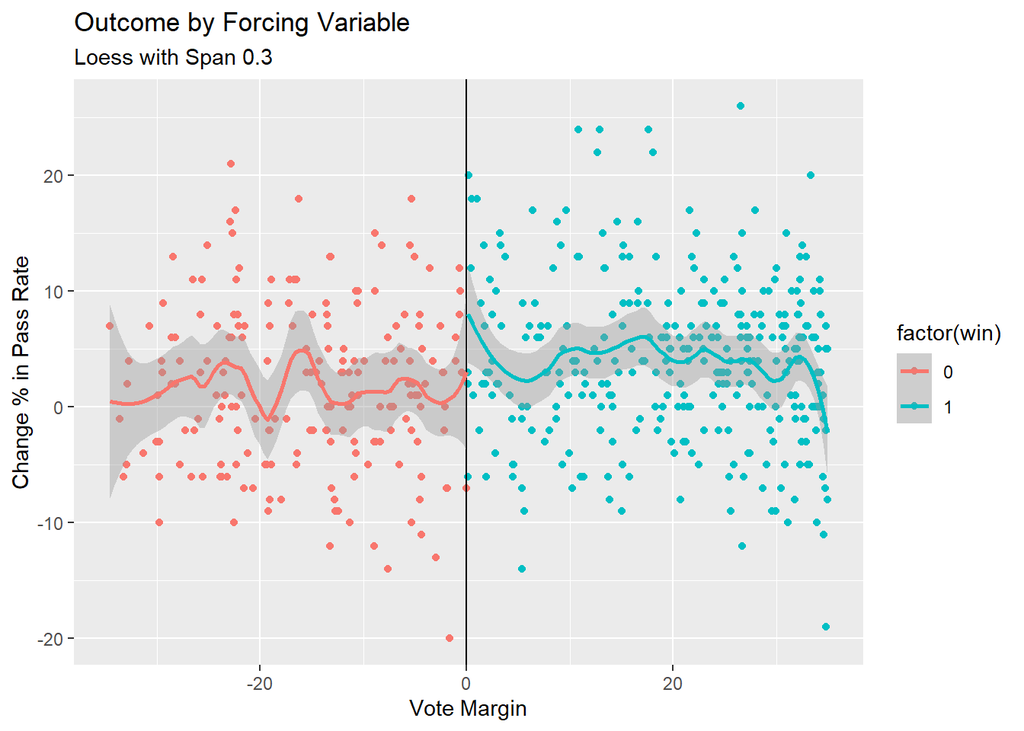

```r
g + geom_smooth(method='loess', span=0.3, aes(color=factor(win))) +
  labs(subtitle='Loess with Span 0.3')
```

Increase bandwith to 0.5.

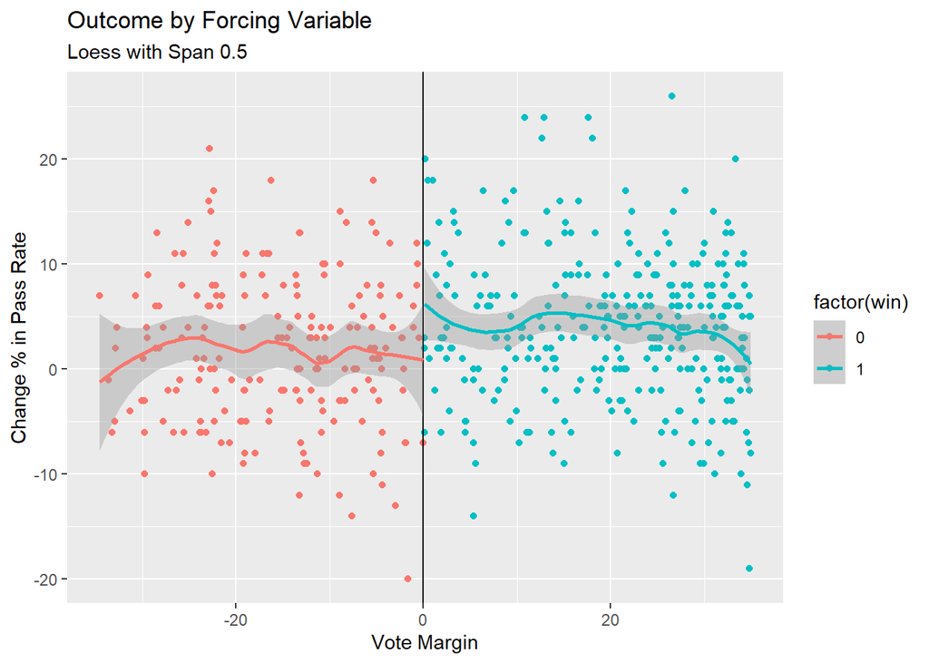

```r
g + geom_smooth(method='loess', span=0.5, aes(color=factor(win))) +
  labs(subtitle='Loess with Span 0.5')
```

Now use linear regression.

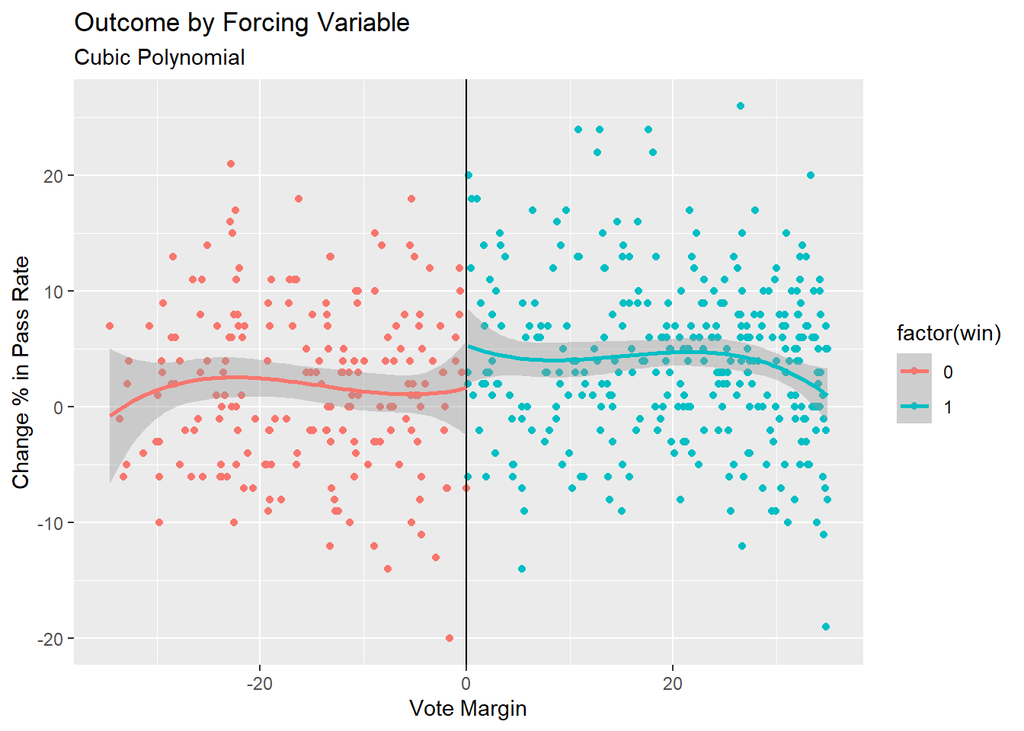

```r
g + geom_smooth(method = 'lm', formula = y ~ splines::bs(x, 3), aes(color=factor(win))) +
  labs(subtitle='Cubic Polynomial')
```

The results are robust to various techniques, and we can claim that the autonomous schools don’t have statistically significant effect on the pass rate of schools.

# Fuzzy RDD

Units with values above a certain threshold value of the underlying variable are more likely to be treated than those below.

## Instrumental Variable

The discontinuity becomes an IV for treatment status. Create interaction terms with instrument for increased complexity. Use 2SLS to estimate the coefficient.

## Problem

Boundary problem from kernel method is that it implies a systematic bias with the method if f(x) is upwards or downwards sloping. Local linear regression solves this problem.

## Optimizing Bandwidth

There are three main methods to choose bandwidth: 1) cross validation 2) optimal bandwith by Imbens and Kalyanaraman 3) robust data-driven inference.

# Difference in Differences (DID)

If we do not have random assignment into treatment (i.e. RCT) to balance unobservables, a valid IV, credible RD design, or cannot use MLR to control for all relevant observables, then we can use DiD. Differnece in Differences method relies on selection on unobservables in the sense that sometimes it is more reasonable to assume that changes in variables (rather than levels) move in parallel.

We pool cross sections of individuals/geographical units/firms on whom some policy is enacted (job training, electoral rule, new regulation). The group exposed to the policy is called treatment group and the group not exposed is control group. Using DiD implies that we compare the difference in outcomes in the treatment and control groups before and after treatment. The data requiremenet is only that we have cross-section ata for the treatment and control groups before and after the policy.

## Applications

1. Frieberg (1998) Divorce Law on Divorce Rate
2. Card (1992) Minimum Wage
3. Autor (2003) Employment Protection
4. Abadie and Gardeazabal (2003) Terrorism and Growth

## Identifying Assumption

The DiD estimate is an unbiased estimator of the causal effect if the average change in the outcome variable would have been the same for the two groups without the treatment (parallel trend assumption).

DiD estimator is superior to Before-After estimator in one important way. BA estimator compares the outcome for the treated group before and after treatment, but this is a causal effect only if there are no other average differences in unobservables before and after policy change. It ignores time and age effects, and is a very strong assumption. Instead, DiD uses control group to difference out other factors and isolate the policy effect, and recovers treatment on the treated.

## Data

Our data examines the effect of workers’ compensation on time out of work. It compares individuals injured before and after increases in the maximum weekly benefit amount. The increases examind in KY and MI raised the benefit amount for high earning individuals by approximately 50% while low earning individuals who were unaffected by the benefit maximum, did not experience a change in their incentives.

```r
df <- read_dta('C:/Users/jihun/Downloads/applied_microeconometrics/INJURY.DTA')
glimpse(df)
```

```
## Rows: 7,150
## Columns: 30
## $ durat    <dbl> 1, 1, 84, 4, 1, 1, 7, 2, 175, 60, 29, 30, 100, 4, 2, 1, 1,...
## $ afchnge  <dbl> 1, 1, 1, 1, 1, 1, 1, 1, 1, 1, 1, 1, 1, 1, 1, 1, 1, 1, 1, 1...
## $ highearn <dbl> 1, 1, 1, 1, 1, 1, 1, 1, 1, 1, 1, 1, 1, 1, 1, 1, 1, 1, 1, 1...
## $ male     <dbl> 1, 1, 1, 1, 1, 1, 1, 1, 1, 1, 1, 1, 1, 1, 1, 0, 1, 1, 1, 1...
## $ married  <dbl> 0, 1, 1, 1, 1, 1, 1, 1, 1, 1, 1, 1, 1, 1, 1, 0, 1, 1, 1, 1...
## $ hosp     <dbl> 1, 0, 1, 1, 0, 0, 0, 1, 1, 1, 0, 1, 1, 0, 0, 0, 0, 0, 1, 1...
## $ indust   <dbl> 3, 3, 3, 3, 3, 3, 3, 3, 3, 3, 3, 3, 3, 3, 3, 3, 3, 3, 3, 1...
## $ injtype  <dbl> 1, 1, 1, 1, 1, 1, 1, 1, 1, 1, 1, 1, 1, 1, 1, 1, 1, 1, 1, 1...
## $ age      <dbl> 26, 31, 37, 31, 23, 34, 35, 45, 41, 33, 35, 25, 39, 27, 24...
## $ prewage  <dbl> 404.9500, 643.8250, 398.1250, 527.8000, 528.9375, 614.2500...
## $ totmed   <dbl> 1187.57324, 361.07855, 8963.65723, 1099.64832, 372.80188, ...
## $ injdes   <dbl> 1010, 1404, 1032, 1940, 1940, 1425, 1110, 1207, 1425, 1010...
## $ benefit  <dbl> 246.8375, 246.8375, 246.8375, 246.8375, 211.5750, 176.3125...
```

[output cut: 17 more lines]

## Stuy Design Limitations

DiD’s important assumption is that there is no other interaction between time and treatment group except for the treatment we study. Thus changes in unobservables over time affect both groups in the same way. Fixed group affects capture unmeasured differences between treated and non-treated.

1. Targeting differences: we want to make sure in the data that treatment wasn’t done due to pre-existing differences in outcome.
2. Functional form dependence: When average levels of the outcome are very different for control and treatments before the policy change, the magnitude or even sign of the DiD effect is very sensitive to funcitonal form.
3. Long term response versus reliability tradeoff: DiD estiates are more reliable when we compare outcomes just before and just after the policy change because the parallel trend is more likely to hold over a short time window.
4. Inference: if observations in the control and treatment group tend to move together and are correlated, then there may be a random effect at the time or group level, so we actually have less information.

## Fit Models and Check Parallel Trend Assumption

I fit Before-After estimator for the treatment group on the subpopulation of highe earners in Kentucky, cross-sectional models, and finally DiD model.

```r
# Get the Before-After estimator for the treatment group.
BA_treatment_mod <- lm(ldurat~afchnge, data=df, subset=(highearn==1 & ky==1))
# Get the Before-After estimator for the control group
BA_control_mod <- lm(ldurat~afchnge, data=df, subset=(highearn==0 & ky==1))
# Get the cross-section estimator on the period after treatment
CS_before_mod <- lm(ldurat~highearn, data=df, subset=(afchnge==1 & ky==1))
# Get the cross-section estimator on the period before treatment
CS_after_mod <- lm(ldurat~highearn, data=df, subset=(afchnge==0 & ky==1))
# Get the complete DiD model
didmod <- lm(ldurat~highearn*afchnge, data=df, subset=(ky==1))
# Summarize the results
stargazer(BA_treatment_mod, BA_control_mod, CS_before_mod, CS_after_mod, didmod, type='text', title='Effect of Raising Benefits on Injury Duration', style='aer')
```

```
##
## Effect of Raising Benefits on Injury Duration
## ============================================================================================================================================
##                                                                              ldurat
##                               (1)                    (2)                    (3)                      (4)                      (5)
## --------------------------------------------------------------------------------------------------------------------------------------------
## afchnge                     0.198***                0.008                                                                    0.008
##                             (0.053)                (0.044)                                                                  (0.045)
##
## highearn:afchnge                                                                                                            0.191***
##                                                                                                                             (0.069)
##
## highearn                                                                  0.447***                 0.256***                 0.256***
##                                                                           (0.050)                  (0.047)                  (0.047)
##
## Constant                    1.382***               1.126***               1.133***                 1.126***                 1.126***
##                             (0.037)                (0.030)                (0.033)                  (0.030)                  (0.031)
##
## Observations                 2,394                  3,232                  2,688                    2,938                    5,626
## R2                           0.006                  0.000                  0.029                    0.010                    0.021
## Adjusted R2                  0.005                  -0.000                 0.029                    0.010                    0.020
## Residual Std. Error    1.299 (df = 2392)      1.247 (df = 3230)      1.284 (df = 2686)        1.255 (df = 2936)        1.269 (df = 5622)
## F Statistic         13.939*** (df = 1; 2392) 0.030 (df = 1; 3230) 79.962*** (df = 1; 2686) 29.863*** (df = 1; 2936) 39.540*** (df = 3; 5622)
## --------------------------------------------------------------------------------------------------------------------------------------------
## Notes:              ***Significant at the 1 percent level.
##                     **Significant at the 5 percent level.
##                     *Significant at the 10 percent level.
```

The change in the policy over time induced around 19.8% increase in the duration on average for high earners in Kentucky. The identifying assumption requires the error term to be uncorrelted with afchnge in the treatment group in order for the causal interpretation. In particular it means that there should be no time trend. This may not be true if the economy may have gotten better over time so that it is easier to get a job before than after they recover.

For the BA estimator on control group. we see the coefficient on afchnge is close to zero. This does not raise doubts about the assumption of no time trend. We can here compute DiD estimator by differencing the coefficients for BA-estimators for treatment and control group.

The regression equation for the Cross-Section estimator after the policy change is run for the observations after the benefit is raised in Kentucky. As shown in the table, high-earners have around 44.7% larger duration than the low earners on average, after the policy change. In order to interpret this as the causal effect of raising benefits, we need to asssume that there is no difference between the high-earners and the low-earners in their injury duration before the policy change. However, this may not hold since high-earners may have more stable job than low earners. The high-earners are secured to return to their previous job while the low-earners may have to find a new job if they are out too long, which induces the low-earners to return quickly.

For the CS estimator before the policy change, high earners have around 25.6% larger duration than the low-earners on average. This raises question on assumption on the CS estimator above. We can here compute DiD estimator by taking the difference between the coefficients after and before groups.

Finally, we have the complete model and the coefficient of 0.191. The main identifying assumption is that the amount of selection bias caused by unobservables stay the same over time except for the unobservables that affect both groups in the same way. In other words, we require that the potential outcomes of high earners and low earners have a common time trend. This means that, if the policy was not implemented, the high earners and the low earners would have shown the same rate of changes in the injury furation over time.

Because of selection bias CS estimator is not credible. We have little evidence of time trend in the data but the complete model didmod remains valid when there was actually time trend, so it is the most credible.

### Feature Selection on the Complete Model

```r
didmod1 <- lm(ldurat ~ afchnge + highearn + afhigh, data=df, subset=(ky==1))
didmod2 <- lm(ldurat~highearn + afhigh, data=df, subset=(ky==1))
didmod3 <- lm(ldurat~afchnge + afhigh, data=df, subset=(ky==1))
stargazer(didmod1, didmod2, didmod3, type='text', style='aer')
```

```
##
## ==============================================================================================
##                                                       ldurat
##                               (1)                      (2)                      (3)
## ----------------------------------------------------------------------------------------------
## afchnge                      0.008                                            -0.100**
##                             (0.045)                                           (0.040)
##
## highearn                    0.256***                 0.253***
##                             (0.047)                  (0.042)
##
## afhigh                      0.191***                 0.198***                 0.447***
##                             (0.069)                  (0.052)                  (0.050)
##
## Constant                    1.126***                 1.129***                 1.233***
##                             (0.031)                  (0.022)                  (0.023)
##
## Observations                 5,626                    5,626                    5,626
## R2                           0.021                    0.021                    0.016
## Adjusted R2                  0.020                    0.020                    0.015
## Residual Std. Error    1.269 (df = 5622)        1.269 (df = 5623)        1.272 (df = 5623)
## F Statistic         39.540*** (df = 3; 5622) 59.305*** (df = 2; 5623) 44.476*** (df = 2; 5623)
## ----------------------------------------------------------------------------------------------
## Notes:              ***Significant at the 1 percent level.
##                     **Significant at the 5 percent level.
##                     *Significant at the 10 percent level.
```

It is not surprising that the coefficient on afhigh is similar for both columns because there is little time-trend. Now the coefficient on the interaction term in the column 3 is much larger because there is a large difference in the baseline injury duration between the high-earners and the low-earners.

### Add controls

```r
didmod_ky <- lm(ldurat~highearn*afchnge+male+married, data=df, subset=(ky==1))
didmod_mi <- lm(ldurat~highearn*afchnge+male+married, data=df, subset=(mi==1))
stargazer(didmod_ky, didmod_mi, type='text', title='Effect of Raising Benefits on Injury Duration in Kentucky and Michigan', style='aer')
```

```
##
## Effect of Raising Benefits on Injury Duration in Kentucky and Michigan
## ====================================================================
##                                          ldurat
##                               (1)                      (2)
## --------------------------------------------------------------------
## highearn                    0.226***                 0.212*
##                             (0.052)                  (0.111)
##
## afchnge                      0.012                    0.096
##                             (0.045)                  (0.086)
##
## male                        -0.084*                 -0.280***
##                             (0.044)                  (0.096)
##
## married                     0.135***                  0.074
##                             (0.039)                  (0.078)
##
## highearn:afchnge            0.224***                  0.165
##                             (0.070)                  (0.155)
##
## Constant                    1.098***                1.589***
##                             (0.048)                  (0.101)
##
## Observations                 5,362                    1,484
## R2                           0.025                    0.017
## Adjusted R2                  0.024                    0.013
## Residual Std. Error    1.260 (df = 5356)        1.369 (df = 1478)
## F Statistic         27.083*** (df = 5; 5356) 4.983*** (df = 5; 1478)
## --------------------------------------------------------------------
## Notes:              ***Significant at the 1 percent level.
##                     **Significant at the 5 percent level.
##                     *Significant at the 10 percent level.
```

After adding the controls, the estimates on interaction term increases to 0.224 and is still statistically significant. The low R-squared suggests large degree of heterogeneity across individuals. If we use panel data and control for the fixed effects, the R-squared may increase significantly. If the fixed effects are highly correlated with the regressors considered here, then the estimates are biased and are useless. But if the fixed estimates are uncorrelated with the regressors, i.e. if they are in fact random effects, then the regression is still useful.

As shown in the second column, the estimate is not statistically signficant for the Michigan sample due to a larger standard error. However, the point estimate suggests the same sign of the effect and the magnitude is somewhat similar to that in Kentucky. The imprecise estimate is due to a smaller sample size in Michigan.

## Visualization

Slope Chart for DiD.

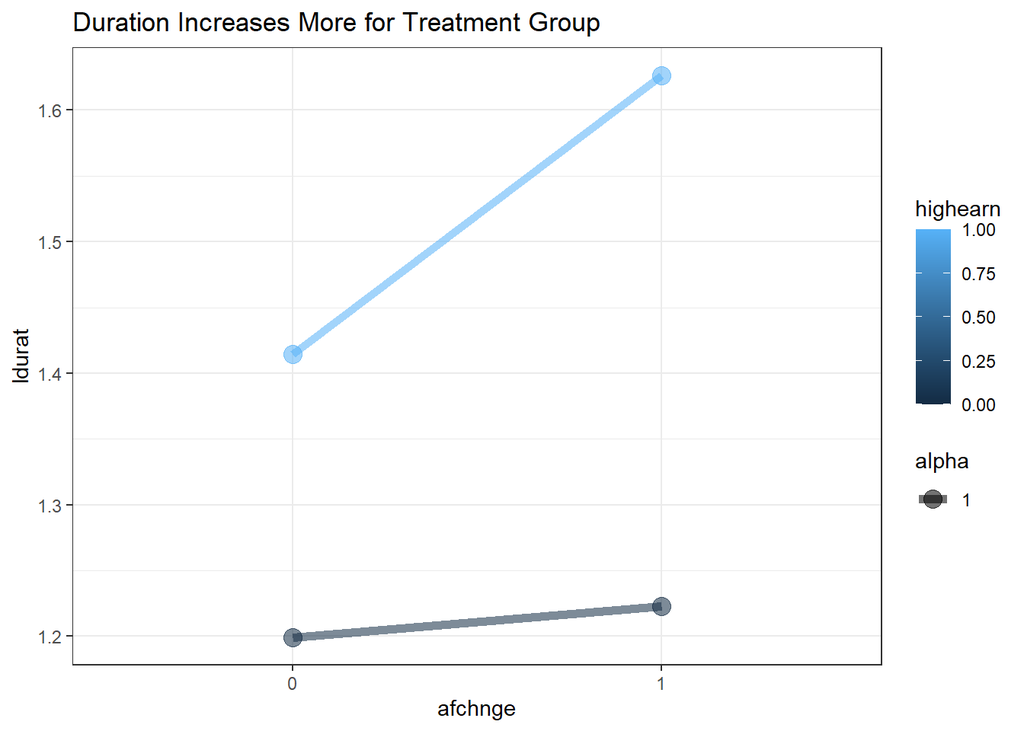

```r
df %>%
  mutate(afchnge = factor(afchnge)) %>%
  group_by(afchnge,highearn) %>%
  summarise(ldurat = mean(ldurat)) %>%
  ggplot(aes(x = afchnge, y = ldurat, group = highearn)) +
    geom_line(aes(color = highearn, alpha = 1), size = 2) +
    geom_point(aes(color = highearn, alpha = 1), size = 4) +
    labs(title='Duration Increases More for Treatment Group') +
    theme_bw()
```

## Three or More Periods

When T>2, DiD lends itself to a test for causality in the spirit of Granger (1969). The Granger idea is to see whether causes happen before consequences and not vice versa. Suppose the policy variable of interest changes at different times in different states. In this context, Granger causality testing means a check of whether, conditional on state and year effects, past treatments predict future outcomes while future treatment does not predict past outcomes.

In our dataset, we can collect one more period of data before the change, and then check whether the high-earners and the low-earners actually show a common time trend before the change.

### Synthetic Control Method

In some cases, treatment and potential control groups do not follow parallel trends and DiD estimator would lead to biased estimates. The basic idea behind it is that a combination of units of ten provides a better comparison for the unit exposed to the intervention than any single unit alone. For instance, you can take a weighted average of other units as a synthetic control group.

# Panel Data Methods

Panel data is data where we observe the same unit (individual/firm/country) over time periods. A common feature of panel data is that sample of individuals is typically large and the number of timme periods is relatively short. There are three types of panel data:

1. Balanced: all identities are observed in all periods
2. Unbalanced: entry, exit, and non-response exist
3. Rotating: a share of the sample is renewed every year

Panel data methods have many benefits:

1. Increase in sample size increases precision of estimates
2. Control individual fixed effects which are common to an individual across time but might vary across agents at any point in time, and this is known as unobserved heterogeneity. This is not possible for cross-section data.
3. void aggregation bias: model behavior at the micro level not suited for aggregation

The key theme in the panel data methods is that if an omitted variable does not change over time, then any changes in Y over time cannot be caused by the omitted variable.

Regression using panel data may mitigate omitted variable bias when there is no information on variables that correlate with both the regressors of interest and the independent variable, and if these variables are constant in the time dimension or across entities.

## Data

We will study two datasets and do the following models:

1. Quasi-Panel Data: two periods concatenated row-wise and different periods marked by a binary column (like DiD data)
- pooled OLS
2. Panel Data: Fatality from Drunk Driving
- First Difference Estimator
- Fixed Effect
- Random Effect

As opposed to DiD, we are considering data from two periods for the same individuals, as opposed to cross-sections from the same populations.

### Dataset 1: Wage Determinants

This is a panel data of workers with two years of wage and its determinants on two periods: 1978 and 1985.

```r
df <- read_dta('C:/Users/jihun/Downloads/applied_microeconometrics/CPS78_85.dta')
glimpse(df)
```

```
## Rows: 1,084
## Columns: 15
## $ educ     <dbl> 12, 12, 6, 12, 12, 8, 11, 15, 16, 15, 15, 12, 11, 12, 12, ...
## $ south    <dbl> 0, 0, 0, 0, 0, 0, 0, 0, 0, 0, 0, 0, 0, 0, 0, 0, 0, 0, 0, 0...
## $ nonwhite <dbl> 0, 0, 0, 0, 0, 0, 0, 0, 0, 0, 0, 0, 0, 0, 0, 0, 0, 0, 0, 1...
## $ female   <dbl> 0, 1, 0, 0, 0, 0, 0, 1, 1, 0, 0, 1, 0, 0, 0, 1, 0, 1, 0, 0...
## $ married  <dbl> 0, 1, 1, 1, 1, 1, 0, 0, 0, 1, 1, 1, 1, 1, 0, 0, 1, 1, 1, 1...
## $ exper    <dbl> 8, 30, 38, 19, 11, 43, 2, 9, 17, 23, 39, 5, 27, 29, 7, 42,...
## $ expersq  <dbl> 64, 900, 1444, 361, 121, 1849, 4, 81, 289, 529, 1521, 25, ...
## $ union    <dbl> 0, 1, 1, 1, 0, 0, 0, 0, 0, 1, 1, 1, 1, 0, 0, 1, 1, 1, 0, 1...
## $ lwage    <dbl> 1.2150, 1.6094, 2.1401, 2.0732, 1.6490, 1.7148, 1.0986, 1....
## $ age      <dbl> 25, 47, 49, 36, 28, 56, 18, 29, 38, 43, 59, 22, 43, 46, 24...
## $ year     <dbl> 78, 78, 78, 78, 78, 78, 78, 78, 78, 78, 78, 78, 78, 78, 78...
## $ y85      <dbl> 0, 0, 0, 0, 0, 0, 0, 0, 0, 0, 0, 0, 0, 0, 0, 0, 0, 0, 0, 0...
## $ y85fem   <dbl> 0, 0, 0, 0, 0, 0, 0, 0, 0, 0, 0, 0, 0, 0, 0, 0, 0, 0, 0, 0...
## $ y85educ  <dbl> 0, 0, 0, 0, 0, 0, 0, 0, 0, 0, 0, 0, 0, 0, 0, 0, 0, 0, 0, 0...
## $ y85union <dbl> 0, 0, 0, 0, 0, 0, 0, 0, 0, 0, 0, 0, 0, 0, 0, 0, 0, 0, 0, 0...
```

## Data Preprocessing

We create two variables: 1. y85educ12: years of education subtracted by 12 2. llwage: inflation adjusted log-waged

```r
df <-
  df %>%
  mutate(y85educ12 = y85*I(educ-12), # this can induce different interpretation for y85 from wage return on person with no education to 12 years of education
         llwage = ifelse(y85==1,I(lwage-log(1.65)),lwage)) # inflation adjusted wage log(wage/inflation) = log(wage) - log(inflation)
glimpse(df)
```

```
## Rows: 1,084
## Columns: 17
## $ educ      <dbl> 12, 12, 6, 12, 12, 8, 11, 15, 16, 15, 15, 12, 11, 12, 12,...
## $ south     <dbl> 0, 0, 0, 0, 0, 0, 0, 0, 0, 0, 0, 0, 0, 0, 0, 0, 0, 0, 0, ...
## $ nonwhite  <dbl> 0, 0, 0, 0, 0, 0, 0, 0, 0, 0, 0, 0, 0, 0, 0, 0, 0, 0, 0, ...
## $ female    <dbl> 0, 1, 0, 0, 0, 0, 0, 1, 1, 0, 0, 1, 0, 0, 0, 1, 0, 1, 0, ...
## $ married   <dbl> 0, 1, 1, 1, 1, 1, 0, 0, 0, 1, 1, 1, 1, 1, 0, 0, 1, 1, 1, ...
## $ exper     <dbl> 8, 30, 38, 19, 11, 43, 2, 9, 17, 23, 39, 5, 27, 29, 7, 42...
## $ expersq   <dbl> 64, 900, 1444, 361, 121, 1849, 4, 81, 289, 529, 1521, 25,...
## $ union     <dbl> 0, 1, 1, 1, 0, 0, 0, 0, 0, 1, 1, 1, 1, 0, 0, 1, 1, 1, 0, ...
## $ lwage     <dbl> 1.2150, 1.6094, 2.1401, 2.0732, 1.6490, 1.7148, 1.0986, 1...
## $ age       <dbl> 25, 47, 49, 36, 28, 56, 18, 29, 38, 43, 59, 22, 43, 46, 2...
## $ year      <dbl> 78, 78, 78, 78, 78, 78, 78, 78, 78, 78, 78, 78, 78, 78, 7...
## $ y85       <dbl> 0, 0, 0, 0, 0, 0, 0, 0, 0, 0, 0, 0, 0, 0, 0, 0, 0, 0, 0, ...
## $ y85fem    <dbl> 0, 0, 0, 0, 0, 0, 0, 0, 0, 0, 0, 0, 0, 0, 0, 0, 0, 0, 0, ...
## $ y85educ   <dbl> 0, 0, 0, 0, 0, 0, 0, 0, 0, 0, 0, 0, 0, 0, 0, 0, 0, 0, 0, ...
## $ y85union  <dbl> 0, 0, 0, 0, 0, 0, 0, 0, 0, 0, 0, 0, 0, 0, 0, 0, 0, 0, 0, ...
## $ y85educ12 <I<dbl>> 0, 0, 0, 0, 0, 0, 0, 0, 0, 0, 0, 0, 0, 0, 0, 0, 0, 0, ...
## $ llwage    <dbl> 1.2150, 1.6094, 2.1401, 2.0732, 1.6490, 1.7148, 1.0986, 1...
```

## Fit Models: Pooled OLS

We fit the follwowing models to estimate the causal effect of union membership, education, and gender.

```r
pmod1 <- lm(lwage ~ y85 + educ + y85educ + exper + expersq + union + female + y85fem, data=df)
pmod2 <- lm(lwage ~ y85 + educ + exper + expersq + union + female + y85fem + y85educ12, data=df)
pmod3 <- lm(llwage ~ y85 + educ + y85educ + exper + expersq + union + female + y85fem, data=df)
pmod4 <- lm(lwage ~ y85 + educ + y85educ + exper + expersq + union + female + y85fem + y85union, data=df)
stargazer(pmod1, pmod2, pmod3, pmod4, type='text', title='Determinants of Wages in 1978 and 1985', style='aer')
```

```
##
## Determinants of Wages in 1978 and 1985
## =======================================================================================================================
##                                           lwage                                llwage                   lwage
##                               (1)                      (2)                      (3)                      (4)
## -----------------------------------------------------------------------------------------------------------------------
## y85                          0.118                   0.339***                -0.383***                  0.118
##                             (0.124)                  (0.034)                  (0.124)                  (0.126)
##
## educ                        0.075***                 0.075***                 0.075***                 0.075***
##                             (0.007)                  (0.007)                  (0.007)                  (0.007)
##
## y85educ                     0.018**                                           0.018**                  0.018**
##                             (0.009)                                           (0.009)                  (0.009)
##
## exper                       0.030***                 0.030***                 0.030***                 0.030***
##                             (0.004)                  (0.004)                  (0.004)                  (0.004)
##
## expersq                    -0.000***                -0.000***                -0.000***                -0.000***
##                             (0.000)                  (0.000)                  (0.000)                  (0.000)
##
## union                       0.202***                 0.202***                 0.202***                 0.202***
##                             (0.030)                  (0.030)                  (0.030)                  (0.039)
##
## female                     -0.317***                -0.317***                -0.317***                -0.317***
##                             (0.037)                  (0.037)                  (0.037)                  (0.037)
##
## y85fem                       0.085*                   0.085*                   0.085*                   0.085
##                             (0.051)                  (0.051)                  (0.051)                  (0.052)
##
## y85educ12                                            0.018**
##                                                      (0.009)
##
## y85union                                                                                                -0.000
##                                                                                                        (0.061)
##
## Constant                    0.459***                 0.459***                 0.459***                 0.459***
##                             (0.093)                  (0.093)                  (0.093)                  (0.095)
##
## Observations                 1,084                    1,084                    1,084                    1,084
## R2                           0.426                    0.426                    0.356                    0.426
## Adjusted R2                  0.422                    0.422                    0.351                    0.421
## Residual Std. Error    0.413 (df = 1075)        0.413 (df = 1075)        0.413 (df = 1075)        0.413 (df = 1074)
## F Statistic         99.804*** (df = 8; 1075) 99.804*** (df = 8; 1075) 74.354*** (df = 8; 1075) 88.632*** (df = 9; 1074)
## -----------------------------------------------------------------------------------------------------------------------
## Notes:              ***Significant at the 1 percent level.
##                     **Significant at the 5 percent level.
##                     *Significant at the 10 percent level.
```

The first model: - the wage return to education in 1978 is around 7.47% (educ). - The wage return to education over this time period has changed by around 1.85 percentage points (y85educ). - The gender wage gap in 1978 is around -31.7% (i.e. women have 31.7% lower wage on average than men). - The gender wage gap over this time period changed has b around 8.51 percentage points (y85fem). This is to say that the wage gap was smaller by 8.51 percentage points.

The second model: - The coefficient on y85 represents how much average wage has changed from 1978 to 1985 for men with no education (years of education equal to 0). - With y85educ12 coefficient we get a different interpretation for coefficient on y85. Now it represents how much average wage has changed from 1978 to 1985 for men with 12 years of education, which is around 33.9%.

The third model: The adjustment of inflation for log wages in 1985 is actually just a linear transformation. After the adjustment, the wages in 1985 are closer to the wages in 1978. Thus the total variation of log wage is smaller. Notice that the variation of log wages is still the same after controlling the year, thus the estimates of the coefficients on all other regressors besides y85 are the same. Therefore, the residuals and the sum of squared residuals are the same. This implies R-squared is now smaller. Only the coefficient on y85 is different, while all others remain almost the same.

#### Limitations

If we have actual panel data instead of quasi-panel data, we could use fixed effects to control for unobserved heterogeneity that is fixed over times within the individual workers. In other words, we would use the variation within a worker to estimate the effect of different regressors on wages (fixed effect model).

### Identifying Assumptions

If the fixed effects are correlated with the independent variables, pooled OLS gives biased estimates, and we have no way of knowing whether this is true.

# Dataset 2: Fatality Rates Across States

```r
data(Fatalities)
# convert df into pdata.frame format with new indices
df <- pdata.frame(Fatalities, index=c('state', 'year'))
# create a fatality rate column: proportion of alcohol-related in the population
df$fatal_rate <- df$afatal / df$pop * 10000
# this one is on vehicle related fatalities
df$fatality_rate <- df$fatal/df$pop * 10000
# create a lagged variable beer table
df <-
  df %>%
  group_by(state) %>%
  mutate(diff_fatal_rate = fatal_rate - lag(fatal_rate),
         diff_beertax = beertax - lag(beertax)) %>%
  ungroup()
glimpse(df)
```

```
## Rows: 336
## Columns: 38
## $ state           <fct> al, al, al, al, al, al, al, az, az, az, az, az, az,...
## $ year            <fct> 1982, 1983, 1984, 1985, 1986, 1987, 1988, 1982, 198...
## $ spirits         <dbl> 1.37, 1.36, 1.32, 1.28, 1.23, 1.18, 1.17, 1.97, 1.9...
## $ unemp           <dbl> 14.4, 13.7, 11.1, 8.9, 9.8, 7.8, 7.2, 9.9, 9.1, 5.0...
## $ income          <dbl> 10544.15, 10732.80, 11108.79, 11332.63, 11661.51, 1...
## $ emppop          <dbl> 50.69204, 52.14703, 54.16809, 55.27114, 56.51450, 5...
## $ beertax         <dbl> 1.53937948, 1.78899074, 1.71428561, 1.65254235, 1.6...
## $ baptist         <dbl> 30.3557, 30.3336, 30.3115, 30.2895, 30.2674, 30.245...
## $ mormon          <dbl> 0.32829, 0.34341, 0.35924, 0.37579, 0.39311, 0.4112...
## $ drinkage        <dbl> 19.00, 19.00, 19.00, 19.67, 21.00, 21.00, 21.00, 19...
## $ dry             <dbl> 25.0063, 22.9942, 24.0426, 23.6339, 23.4647, 23.792...
## $ youngdrivers    <dbl> 0.211572, 0.210768, 0.211484, 0.211140, 0.213400, 0...
## $ miles           <dbl> 7233.887, 7836.348, 8262.990, 8726.917, 8952.854, 9...
```

[output cut: 25 more lines]

When one only looks at the correlation between beer tax and fatality rate, there is a positive correlation. This is because we are not controlling for other factors such as quality of cars, roads, culture of drink-driving, traffic density, poverty, social problems and higher taxes, etc. These omitted variables are creating a bias on the causal effect. If all these unobserved variables are constant across time, panel data allows us to bypass the bias caused by them.

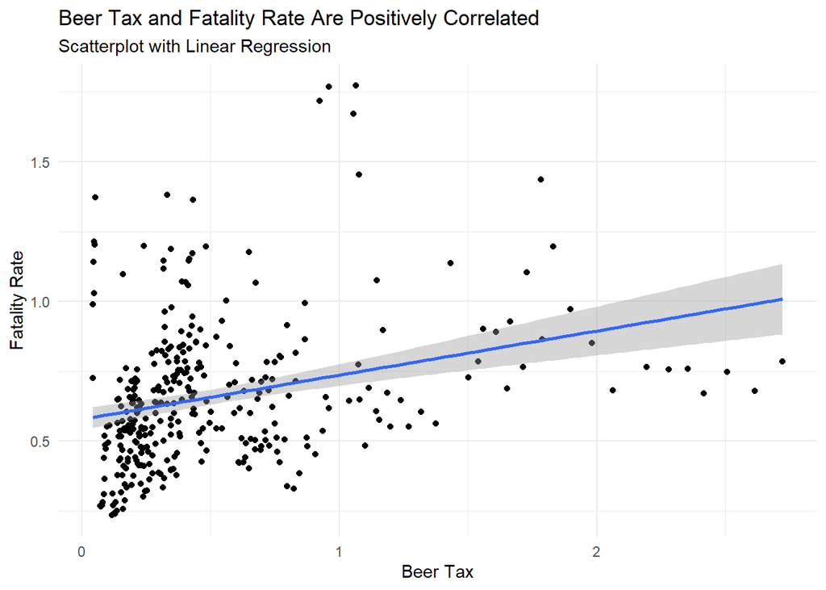

```r
ggplot(df, aes(x=beertax, y=fatal_rate)) +
  geom_point() +
  geom_smooth(method='lm') +
  theme_minimal() +
  labs(title='Beer Tax and Fatality Rate Are Positively Correlated',
       x='Beer Tax',
       y='Fatality Rate',
       subtitle='Scatterplot with Linear Regression')
```

# Fitting Panel Data Models

1. Pooled OLS
2. First Difference
3. Fixed Effect on Individuals
4. Fixed Effect on Individuals and Time Effect
5. Random Effect

## Pooled OLS

Naive model of running OLS on data.

```r
poolmod <- plm(fatal_rate ~ beertax + gsp + breath + jail + service + drinkage + dry + spirits, data=df, model='pooling')
summary(poolmod)
```

```
## Pooling Model
##
## Call:
## plm(formula = fatal_rate ~ beertax + gsp + breath + jail + service +
##     drinkage + dry + spirits, data = df, model = "pooling")
##
## Unbalanced Panel: n = 48, T = 6-7, N = 335
##
## Residuals:
##      Min.   1st Qu.    Median   3rd Qu.      Max.
## -0.461756 -0.157343 -0.030305  0.094981  1.036024
##
## Coefficients:
##               Estimate Std. Error t-value  Pr(>|t|)
## (Intercept)  0.9980880  0.2994764  3.3328 0.0009587 ***
## beertax      0.1555814  0.0268155  5.8019 1.552e-08 ***
## gsp         -1.6722228  0.3029755 -5.5193 6.951e-08 ***
## breathyes   -0.0473591  0.0267723 -1.7690 0.0778357 .
## jailyes      0.1561560  0.0351678  4.4403 1.231e-05 ***
## serviceyes  -0.0353577  0.0384929 -0.9186 0.3590097
## drinkage    -0.0232392  0.0142227 -1.6340 0.1032327
## dry          0.0068132  0.0013850  4.9193 1.380e-06 ***
## spirits      0.0312674  0.0198635  1.5741 0.1164315
## ---
## Signif. codes:  0 '***' 0.001 '**' 0.01 '*' 0.05 '.' 0.1 ' ' 1
##
## Total Sum of Squares:    22.542
## Residual Sum of Squares: 15.864
## R-Squared:      0.29623
## Adj. R-Squared: 0.27896
## F-statistic: 17.1521 on 8 and 326 DF, p-value: < 2.22e-16
```

## First Difference Model

We create new variables that represent the year-to-year change in each variable within a state: the change in the fatality rate in Alabama between 1982 and 1983, between 1983 and 1984, and so on. We then run the regression in these differences. This is closely related to the regression we ran above looking at the change between 1982 and 1988, but in this case we use all the year-to-year changes.

### First Difference Model (two-period: 1982 and 1988)

Take a first difference across two time periods, and this will remove the effect of omitted variable.

```r
# subset the data
Fatalities1982 <- subset(df, year == "1982")
Fatalities1988 <- subset(df, year == "1988")
# compute the differences
diff_fatal_rate <- Fatalities1988$fatal_rate - Fatalities1982$fatal_rate
diff_beertax <- Fatalities1988$beertax - Fatalities1982$beertax
# estimate a regression using differenced data
fatal_diff_mod <- lm(diff_fatal_rate ~ diff_beertax)
coeftest(fatal_diff_mod, vcov = vcovHC, type = "HC1")
```

```
##
## t test of coefficients:
##
##               Estimate Std. Error t value  Pr(>|t|)
## (Intercept)  -0.140571   0.032252 -4.3585 7.285e-05 ***
## diff_beertax -0.246778   0.285572 -0.8642     0.392
## ---
## Signif. codes:  0 '***' 0.001 '**' 0.01 '*' 0.05 '.' 0.1 ' ' 1
```

### First Difference Model (all periods: 1982~1988)

```r
fdmod <- plm(fatal_rate ~ beertax + gsp + breath + jail + service + drinkage + dry + spirits, data = df, model = "fd")
summary(fdmod)
```

```
## Oneway (individual) effect First-Difference Model
##
## Call:
## plm(formula = fatal_rate ~ beertax + gsp + breath + jail + service +
##     drinkage + dry + spirits, data = df, model = "fd")
##
## Unbalanced Panel: n = 48, T = 6-7, N = 335
## Observations used in estimation: 287
##
## Residuals:
##       Min.    1st Qu.     Median    3rd Qu.       Max.
## -0.5718594 -0.0508466  0.0017233  0.0640556  1.1895587
##
## Coefficients:
##               Estimate Std. Error t-value Pr(>|t|)
## (Intercept) -0.0193690  0.0115459 -1.6776 0.094557 .
## beertax      0.0716215  0.2012389  0.3559 0.722183
## gsp          0.3148350  0.1929931  1.6313 0.103953
## breathyes   -0.1327852  0.0441233 -3.0094 0.002858 **
## jailyes      0.1114842  0.0970386  1.1489 0.251599
## serviceyes  -0.1544446  0.1156278 -1.3357 0.182738
## drinkage     0.0034263  0.0203266  0.1686 0.866265
## dry          0.0077593  0.0135911  0.5709 0.568524
## spirits      0.0202424  0.1184001  0.1710 0.864375
## ---
## Signif. codes:  0 '***' 0.001 '**' 0.01 '*' 0.05 '.' 0.1 ' ' 1
##
## Total Sum of Squares:    5.4692
## Residual Sum of Squares: 5.2066
## R-Squared:      0.048023
## Adj. R-Squared: 0.020628
## F-statistic: 1.75297 on 8 and 278 DF, p-value: 0.086358
```

### Identifying Assumptions:

There are certain problems inherent to the First Difference Estimator and key identifying assumptions:

1. Since we take out all the time-independent variation in the independent variables, we effectively reduce the amount of variation we can use in estimation, implying that estiation using first difference can become very imprecise and have higher standard error. This is a problem that can be solved as we increase sample size.
2. However, attenuation bias from measurement error is irreducible and in fact amplifies because noise tends to be time variant. Measurement error introduces greater standard error and cause bias.
3. We want strict exogeneity, and this assumption could be violated if we have omitted an important time-variant variable. This means future independent variable should not depend on current changes in the idiosyncatic errors. The omitted variable bias causes bias in the estimate.
4. We also need differenced errors to be uncorrelated for the standard errors and test statistics to be valid. Interestingly, uncorrelated original errors can have first differened errors that are in fact correlated over time. The serial correlation in the first differenced errors does not cause bias but the estimated standard errors are incorrect and can cause biass.

We need to make sure the fixed effect is uncorrelated with the independent variables or else the coefficient is biased.

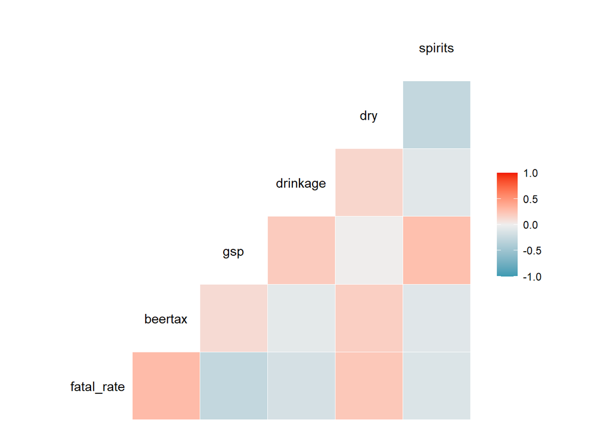

```r
subdf <- df[,c('fatal_rate','beertax','gsp','breath','jail','service','drinkage','dry','spirits')]
print(ggcorr(subdf, method = c("everything", "pearson")))
```

Another way to check correlation among variables.

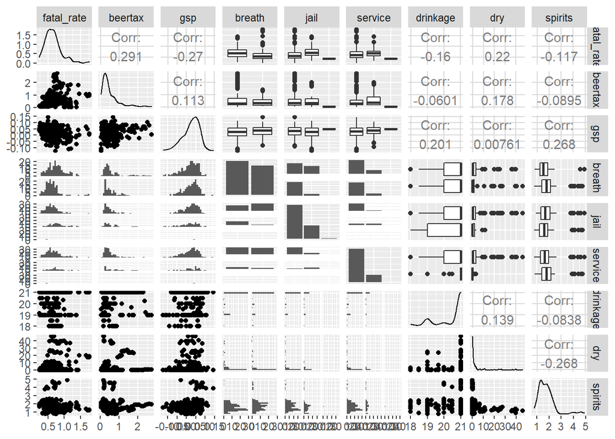

```r
print(ggpairs(subdf, progress=F))
```

Did we omit any important time varying variable? If we do, the strict exogeneity assumption could be violated and the future X should not depend on current changes in the idiosyncratic errors.

#### Testing for Serial Correlation

When change in errors is uncorrelated over time, the standard errors and test statistics are valid. If there is a serial correlation, then the estimated standard errors are incorrect.

```r
pbgtest(fdmod) # null=no serial correlation
```

```
##
##  Breusch-Godfrey/Wooldridge test for serial correlation in panel models
##
## data:  fatal_rate ~ beertax + gsp + breath + jail + service + drinkage +     dry + spirits
## chisq = 20.766, df = 6, p-value = 0.002021
## alternative hypothesis: serial correlation in idiosyncratic errors
```

#### Testing for Unit roots/stationarity

```r
adf.test(df$fatal_rate, k=2) # null hypothesis: unit roots are present
```

```
##
##  Augmented Dickey-Fuller Test
##
## data:  df$fatal_rate
## Dickey-Fuller = -6.5456, Lag order = 2, p-value = 0.01
## alternative hypothesis: stationary
```

## Fixed Effect Model

Having individual specific intercepts capture heterogeneities across entities. Each intercept is dropped because each unit’s own intercept is calculated. It allows us to control for unobserved time-independent factors and estimate effect of variables that do vary over time, potentially reducing bias or inconsistency. Fixed effect model is also called within estimator, and time demean all variables within modelling process (unlike FD where we take a difference between the previous values).

Just like First Difference, the model reduces the total amount of variation in the data that exacerbates attenuation bias due to measurement error in the independent variables. In fact, when there are only two periods, the fixed effect model and the first difference model are the same. However, when there are more than two periods, FE and FD are not equivalent, although they are both unbiased given that all the relevant assumptions hold.

Time demeaning in Fixed Effect model implies we look at deviations in the variables from average for each individual over the period. On the other hand, FD implies that we look at period-to-period changes in the variables. Per-period changes may not be the same as deviations from the average over all time periods. Since both FE and FD are unbiased given the assumptions are true, we may choose between FE and FD depending on their relative efficiency. The efficency in turn depends on the serial correlation in the idiosyncratic errors U_it. If they are serially uncorrelated, FE is more efficient. If first differenced errors are serially uncorrelated, FD is more efficient. In sum, the choice between FD and FE hinges on serial correlation of errors and first differenced errors. If T is large and N is small, FE can be very sensitive to violations of the classical fixed effect, and should not be used.

The greatest benefit of FE model is that we do not have to assume that time-independent variables are uncorrelated with the independent variables of interest. plm() does not give us coefficients for fixed effects, but we can back them out using OLS. In effect, the FE model runs the pooled regression with a complete set of state dummy variables.

```r
fe_mod1 <- plm(fatal_rate ~ beertax + gsp + breath + jail + service + drinkage + dry + spirits,
              data = df,
              model = "within",
              effect='individual')
summary(fe_mod1)
```

```
## Oneway (individual) effect Within Model
##
## Call:
## plm(formula = fatal_rate ~ beertax + gsp + breath + jail + service +
##     drinkage + dry + spirits, data = df, effect = "individual",
##     model = "within")
##
## Unbalanced Panel: n = 48, T = 6-7, N = 335
##
## Residuals:
##       Min.    1st Qu.     Median    3rd Qu.       Max.
## -0.9611301 -0.0572586 -0.0024756  0.0522149  0.4649044
##
## Coefficients:
##              Estimate Std. Error t-value  Pr(>|t|)
## beertax    -0.2608836  0.1320805 -1.9752   0.04923 *
## gsp         0.1370988  0.2337551  0.5865   0.55801
## breathyes  -0.0168124  0.0401063 -0.4192   0.67540
## jailyes     0.1872312  0.0984175  1.9024   0.05815 .
## serviceyes -0.1631787  0.1126591 -1.4484   0.14862
## drinkage    0.0069354  0.0141131  0.4914   0.62352
## dry         0.0045011  0.0106439  0.4229   0.67271
## spirits     0.3365342  0.0604143  5.5704 5.979e-08 ***
## ---
## Signif. codes:  0 '***' 0.001 '**' 0.01 '*' 0.05 '.' 0.1 ' ' 1
##
## Total Sum of Squares:    5.3854
## Residual Sum of Squares: 4.6066
## R-Squared:      0.14462
## Adj. R-Squared: -0.024007
## F-statistic: 5.89622 on 8 and 279 DF, p-value: 5.5849e-07
```

Controlling for variables that are constant across entities but vary over time can be done by including time fixed effects. The combined model allows to eliminate bias from unobservables that change over time but are constant over entities and it controls for factors that differ across entities but are constant over time. Such models can be estimated using the OLS algorithm that is implemented in R. Note that plm() uses the entity-demeaned OLS algorithm and thus does not report dummy coefficients.

```r
fe_mod2 <- plm(fatal_rate ~ beertax + gsp + breath + jail + service + drinkage + dry + spirits,
              data = df,
              model = "within",
              effect='twoways')
summary(fe_mod2)
```

```
## Twoways effects Within Model
##
## Call:
## plm(formula = fatal_rate ~ beertax + gsp + breath + jail + service +
##     drinkage + dry + spirits, data = df, effect = "twoways",
##     model = "within")
##
## Unbalanced Panel: n = 48, T = 6-7, N = 335
##
## Residuals:
##        Min.     1st Qu.      Median     3rd Qu.        Max.
## -9.2021e-01 -5.1456e-02 -3.5949e-05  4.9471e-02  4.3303e-01
##
## Coefficients:
##               Estimate  Std. Error t-value  Pr(>|t|)
## beertax    -0.23555974  0.13313635 -1.7693  0.077958 .
## gsp         1.00976468  0.32463956  3.1104  0.002066 **
## breathyes  -0.00519473  0.03905600 -0.1330  0.894286
## jailyes     0.21703929  0.09641663  2.2511  0.025178 *
## serviceyes -0.17548983  0.11057013 -1.5871  0.113639
## drinkage    0.00069322  0.01442531  0.0481  0.961707
## dry         0.00065790  0.01035837  0.0635  0.949404
## spirits     0.37094677  0.09287833  3.9939 8.363e-05 ***
## ---
## Signif. codes:  0 '***' 0.001 '**' 0.01 '*' 0.05 '.' 0.1 ' ' 1
##
## Total Sum of Squares:    4.8086
## Residual Sum of Squares: 4.2355
## R-Squared:      0.11917
## Adj. R-Squared: -0.077645
## F-statistic: 4.61688 on 8 and 273 DF, p-value: 2.6551e-05
```

Control for heteroskedasticity.

```r
# print summary using robust standard errors
coeftest(fe_mod2, vcov. = vcovHC, type = "HC1")
```

```
##
## t test of coefficients:
##
##               Estimate  Std. Error t value  Pr(>|t|)
## beertax    -0.23555974  0.21407001 -1.1004 0.2721331
## gsp         1.00976468  0.29604892  3.4108 0.0007457 ***
## breathyes  -0.00519473  0.05514463 -0.0942 0.9250179
## jailyes     0.21703929  0.01257321 17.2620 < 2.2e-16 ***
## serviceyes -0.17548983  0.08146491 -2.1542 0.0321014 *
## drinkage    0.00069322  0.01838745  0.0377 0.9699538
## dry         0.00065790  0.02112529  0.0311 0.9751785
## spirits     0.37094677  0.09398167  3.9470 0.0001007 ***
## ---
## Signif. codes:  0 '***' 0.001 '**' 0.01 '*' 0.05 '.' 0.1 ' ' 1
```

### Identifying Assumptions of Fixed Effect Model

1. Strict exogeneity - We must assume strict exogeneity of the explanatory variables which implies that each error should be uncorrelated not only with the independent variables in the given period, but also with all the independent variables in all other periods. This is the key assumption for FE to give unbiased estimates.
2. Uncorrelated errors gives correct standard errors.

```r
pbgtest(fe_mod1) # null=no serial correlation
```

```
##
##  Breusch-Godfrey/Wooldridge test for serial correlation in panel models
##
## data:  fatal_rate ~ beertax + gsp + breath + jail + service + drinkage +     dry + spirits
## chisq = 52.154, df = 6, p-value = 1.737e-09
## alternative hypothesis: serial correlation in idiosyncratic errors
```

We conclude that the estimated relationship between traffic fatalities and the real beer tax is not affected by omitted variable bias due to factors that are constant over time.

```r
pbgtest(fe_mod2)
```

```
##
##  Breusch-Godfrey/Wooldridge test for serial correlation in panel models
##
## data:  fatal_rate ~ beertax + gsp + breath + jail + service + drinkage +     dry + spirits
## chisq = 50.912, df = 6, p-value = 3.085e-09
## alternative hypothesis: serial correlation in idiosyncratic errors
```

### Robust Standard Errors for Twoway Fixed Effect Models

When there is both heteroskedasticity and autocorrelation, the so-called heteroskedasticity and autocorrelation-consistent (HAC) standard errors need to be used. Clustered standard errors belong to these type of standard errors. They allow for heteroskedasticity and autocorrelated errors within an entity but not correlation across entities.

```r
coeftest(fe_mod2, vcov = vcovHC, type = "HC1")
```

```
##
## t test of coefficients:
##
##               Estimate  Std. Error t value  Pr(>|t|)
## beertax    -0.23555974  0.21407001 -1.1004 0.2721331
## gsp         1.00976468  0.29604892  3.4108 0.0007457 ***
## breathyes  -0.00519473  0.05514463 -0.0942 0.9250179
## jailyes     0.21703929  0.01257321 17.2620 < 2.2e-16 ***
## serviceyes -0.17548983  0.08146491 -2.1542 0.0321014 *
## drinkage    0.00069322  0.01838745  0.0377 0.9699538
## dry         0.00065790  0.02112529  0.0311 0.9751785
## spirits     0.37094677  0.09398167  3.9470 0.0001007 ***
## ---
## Signif. codes:  0 '***' 0.001 '**' 0.01 '*' 0.05 '.' 0.1 ' ' 1
```

Use Arellano method.

```r
coeftest(fe_mod2, vcovHC(fe_mod2,method='arellano'))
```

```
##
## t test of coefficients:
##
##               Estimate  Std. Error t value  Pr(>|t|)
## beertax    -0.23555974  0.21149851 -1.1138 0.2663594
## gsp         1.00976468  0.29249265  3.4523 0.0006441 ***
## breathyes  -0.00519473  0.05448221 -0.0953 0.9241090
## jailyes     0.21703929  0.01242217 17.4719 < 2.2e-16 ***
## serviceyes -0.17548983  0.08048632 -2.1804 0.0300842 *
## drinkage    0.00069322  0.01816657  0.0382 0.9695887
## dry         0.00065790  0.02087153  0.0315 0.9748768
## spirits     0.37094677  0.09285272  3.9950 8.326e-05 ***
## ---
## Signif. codes:  0 '***' 0.001 '**' 0.01 '*' 0.05 '.' 0.1 ' ' 1
```

Use type 3 method.

```r
coeftest(fe_mod2, vcovHC(fe_mod2, type='HC3'))
```

```
##
## t test of coefficients:
##
##               Estimate  Std. Error t value  Pr(>|t|)
## beertax    -0.23555974  0.23171204 -1.0166 0.3102412
## gsp         1.00976468  0.29980996  3.3680 0.0008661 ***
## breathyes  -0.00519473  0.05869095 -0.0885 0.9295363
## jailyes     0.21703929  0.01282704 16.9204 < 2.2e-16 ***
## serviceyes -0.17548983  0.09407059 -1.8655 0.0631822 .
## drinkage    0.00069322  0.01868679  0.0371 0.9704349
## dry         0.00065790  0.02183229  0.0301 0.9759821
## spirits     0.37094677  0.09368856  3.9594 9.593e-05 ***
## ---
## Signif. codes:  0 '***' 0.001 '**' 0.01 '*' 0.05 '.' 0.1 ' ' 1
```

### Testing Time-fixed effects

Test for whether model needs time effects on the fixed effect model.

```r
pFtest(fe_mod1, fe_mod2) # if the pvalue is low, then we dont need to use time-fixed effect
```

```
##
##  F test for individual effects
##
## data:  fatal_rate ~ beertax + gsp + breath + jail + service + drinkage +  ...
## F = 3.7456, df1 = -6, df2 = 279, p-value = NA
## alternative hypothesis: significant effects
```

## Random Effect Model

If we assume that unobserved time-invariant variable is uncorrelated with the independent variable (unlike fixed effect and first difference model where we control for unobserved variable), then we should use a random effect model.

RE model allows us to correct for the serial correlation caused by the fixed effects. It is part of larger family called Generalized Least Squares. When theta is equal to 0, it becomes pooled OLS estimator. When theta is 1, it becomes FE estimator.

```r
re_mod <- plm(fatal_rate ~ beertax + gsp + breath + jail + service + drinkage + dry + spirits, data=df, model='random')
summary(re_mod)
```

```
## Oneway (individual) effect Random Effect Model
##    (Swamy-Arora's transformation)
##
## Call:
## plm(formula = fatal_rate ~ beertax + gsp + breath + jail + service +
##     drinkage + dry + spirits, data = df, model = "random")
##
## Unbalanced Panel: n = 48, T = 6-7, N = 335
##
## Effects:
##                   var std.dev share
## idiosyncratic 0.01651 0.12850 0.364
## individual    0.02888 0.16994 0.636
## theta:
##    Min. 1st Qu.  Median    Mean 3rd Qu.    Max.
##  0.7051  0.7252  0.7252  0.7249  0.7252  0.7252
##
## Residuals:
##     Min.  1st Qu.   Median     Mean  3rd Qu.     Max.
## -0.76523 -0.08021 -0.01850  0.00003  0.05178  0.57993
##
## Coefficients:
##               Estimate Std. Error z-value Pr(>|z|)
## (Intercept)  0.8104339  0.2953558  2.7439 0.006071 **
## beertax      0.1066438  0.0540508  1.9730 0.048493 *
## gsp         -0.2196300  0.2357502 -0.9316 0.351532
## breathyes   -0.0657353  0.0340562 -1.9302 0.053582 .
## jailyes      0.1700979  0.0591842  2.8740 0.004053 **
## serviceyes  -0.1250844  0.0677973 -1.8450 0.065041 .
## drinkage    -0.0188216  0.0128269 -1.4674 0.142280
## dry          0.0075357  0.0028914  2.6062 0.009154 **
## spirits      0.0903877  0.0345086  2.6193 0.008812 **
## ---
## Signif. codes:  0 '***' 0.001 '**' 0.01 '*' 0.05 '.' 0.1 ' ' 1
##
## Total Sum of Squares:    6.6764
## Residual Sum of Squares: 6.0028
## R-Squared:      0.1009
## Adj. R-Squared: 0.078833
## Chisq: 36.583 on 8 DF, p-value: 1.373e-05
```

### Hausman Test

Fixed Effect model v random effect model.

```r
phtest(fe_mod2, re_mod) # null hypothesis: errors are not correlated with the regressors
```

```
##
##  Hausman Test
##
## data:  fatal_rate ~ beertax + gsp + breath + jail + service + drinkage +  ...
## chisq = 64.156, df = 8, p-value = 7.086e-11
## alternative hypothesis: one model is inconsistent
```

```r
# if pvalue is low, then we need to use fixed effects
```

## Testing for Random Effect: Breusch-Pagan Lagrange Multiplier

Is there a significant random effect?

```r
plmtest(re_mod, type=c('bp')) # Breusch-Pagan Lagrange Multiplier for random effects; null is no panel effect (i.e. OLS better)
```

```
##
##  Lagrange Multiplier Test - (Breusch-Pagan) for unbalanced panels
##
## data:  fatal_rate ~ beertax + gsp + breath + jail + service + drinkage +  ...
## chisq = 309.55, df = 1, p-value < 2.2e-16
## alternative hypothesis: significant effects
```

### Putting It All Together: Pooled OLS, FD, FE, and RE

1. Pooled OLS uses an unweighte average of the within and between variation.
2. FE only uses within-variation.
3. RE uses both between and within variation, but weights these sources of variation in a different way compared to OLS.

If the assumption that unobserved time-invariant variable A is uncorrelated with independent variable X for all periods and individuals, then all the models - OLS, FE, and RE - have unbiased estimates.

Standard errors from FD, FE, and RE will typically be correct, but RE will have lower standard errors since it also makes use of the between variation in the data. On the other hand, standard errors from pooled OLS will be incorrect and too low on average because we dont adjust for serial correlation in the error term.

RE allows us to overcome problems with fixed effects. Unlike FE, RE allows us to estimate the effect of time independent variables. If covariance between X and A is zero, then RE is consistent and more efficient since the cross-sectional variation in the data is not thrown out. However, when covariance is non-zero, only FE is consistent. RE and FE differ in what is assumed by the intercept, and RE views this as randomly drawn or part of the error term.

```r
rob_se <- list(sqrt(diag(vcovHC(poolmod, type = "HC1"))),
               sqrt(diag(vcovHC(fdmod, type = "HC1"))),
               sqrt(diag(vcovHC(fe_mod1, type = "HC1"))),
               sqrt(diag(vcovHC(fe_mod2, type = "HC1"))),
               sqrt(diag(vcovHC(re_mod, type = "HC1"))))
stargazer(poolmod, fdmod, fe_mod1, fe_mod2, re_mod, type='text', title='Comparison of Panel Data Models', column.labels=c('Pooled OLS', 'First Difference', 'State FE', 'St-Yr FE', 'RE'), style='aer', model.numbers=F)
```

```
##
## Comparison of Panel Data Models
## =================================================================================================================
##                                                           fatal_rate
##                    Pooled OLS          First Difference          State FE               St-Yr FE           RE
## -----------------------------------------------------------------------------------------------------------------
## beertax             0.156***                0.072                -0.261**               -0.236*          0.107**
##                      (0.027)               (0.201)               (0.132)                (0.133)          (0.054)
##
## gsp                 -1.672***               0.315                 0.137                 1.010***         -0.220
##                      (0.303)               (0.193)               (0.234)                (0.325)          (0.236)
##
## breathyes            -0.047*              -0.133***               -0.017                 -0.005          -0.066*
##                      (0.027)               (0.044)               (0.040)                (0.039)          (0.034)
##
## jailyes             0.156***                0.111                 0.187*                0.217**         0.170***
##                      (0.035)               (0.097)               (0.098)                (0.096)          (0.059)
##
## serviceyes           -0.035                 -0.154                -0.163                 -0.175          -0.125*
##                      (0.038)               (0.116)               (0.113)                (0.111)          (0.068)
##
## drinkage             -0.023                 0.003                 0.007                  0.001           -0.019
##                      (0.014)               (0.020)               (0.014)                (0.014)          (0.013)
##
## dry                 0.007***                0.008                 0.005                  0.001          0.008***
##                      (0.001)               (0.014)               (0.011)                (0.010)          (0.003)
##
## spirits               0.031                 0.020                0.337***               0.371***        0.090***
##                      (0.020)               (0.118)               (0.060)                (0.093)          (0.035)
##
## Constant            0.998***               -0.019*                                                      0.810***
##                      (0.299)               (0.012)                                                       (0.295)
##
## Observations           335                   287                   335                    335              335
## R2                    0.296                 0.048                 0.145                  0.119            0.101
## Adjusted R2           0.279                 0.021                 -0.024                 -0.078           0.079
## F Statistic  17.152*** (df = 8; 326) 1.753* (df = 8; 278) 5.896*** (df = 8; 279) 4.617*** (df = 8; 273) 36.583***
## -----------------------------------------------------------------------------------------------------------------
## Notes:       ***Significant at the 1 percent level.
##              **Significant at the 5 percent level.
##              *Significant at the 10 percent level.
```